# 프로젝트 제안서(기획서)

NASA Batttery

2024-05-02

## 1. 데이터 설명 및 원본 데이터 요약 결과

### (1) 분석 데이터

- 충전, 방전, 임피던스의 세가지 다른 운영과정을 적용한 리튬 이온 배터리

### (2) 실험 단계별 데이터 특징

#### 가. 충전과정(2가지 단계)

- 1. 정전류 단계(CC): 배터리는 1.5A의 일정한 전류로 충전되고 배터리의 전압이 4.2V에 도달할 때까지 지속
- 2. 정전압 단계(CV): 배터리 전압이 4.2V에 도달 한 후 전압은 일정하게 유지되고 전류가 20mA로 떨어질 때까지 충전이 지속

#### 나. 방전과정

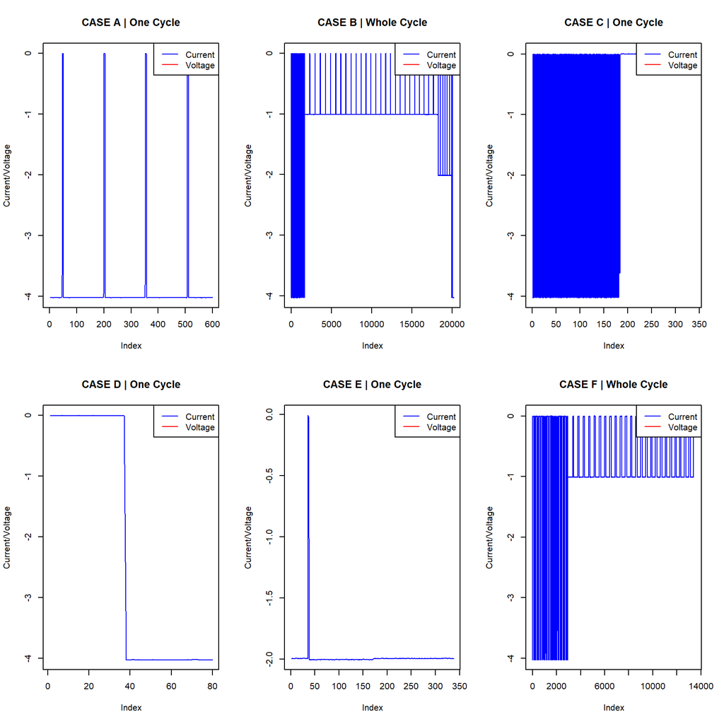

#### 다. 임피던스 측정

- 전기화학 임피던스 분광법(EIS)을 사용하여 0.1Hz에서 5KHz까지의 주파수 스윕을 통해 이루어 지고 이를 통해 배터리 내부의 저항을 평가하여 배터리의 상태와 효율을 이해하는 데 사용
- 전기회로 형태로 내부 저항의 모습을 도식화 하고 이를 기반으로 임피던스 값을 해석
- 전류가 흐를 때 회로가 가하는 반발이나 저항을 나타내는 개념이며 사람의 몸 안 상태(근육량, 체지방량, 수분량 등)를 알기 위해 인바디 검사를 하는 것과 유사

#### 라. 실험 조건

| 실험조건 | 온도 | 운전조건(충전) | 운전조건(방전) | 배터리번호 |
| --- | --- | --- | --- | --- |
| A | 43 | 충전 : CC(1.5A)-CV(4.2V) | 방전 : CC(4A)-diff Voltage | 29,30,31,32 |
| B | 24&44 | 충전 : CC(1.5A)-CV(4.2V) | 방전 : Multiple Load(1A,2A,4A)-diff Voltage | 38,39,40 |
| C | 24 | 충전 : CC(1.5A)-CV(4.2V) | 방전 : 4A 진폭 방전-diff Voltage | 25,26,27,28 |
| D | 24 | 충전 : CC(1.5A)-CV(4.2V) | 방전 : CC(4A)-diff Voltage | 33,34,36 |
| E | 24 | 충전 : CC(1.5A)-CV(4.2V) | 방전 : CC(2A)-2.7V | 36 |
| F | 4 | 충전 : CC(1.5A)-CV(4.2V) | 방전 : Multiple Fixed Load(4A, 1A)-diff Voltage | 41,42,43,44 |

### (3) 원본 데이터 요약 결과

- 원본데이터가 MatFile로 CSV로 변환하여 전처리 진행
- 데이터 : 사이클링 실험 데이터, 용량 데이터로 분리

- Voltage_measured: 측정된 배터리 단자 전압
- Current_measured: 측정된 배터리 출력 전류
- Temperature_measured: 측정된 배터리 온도
- Current_charge: 충전기에서 측정된 전류
- Voltage_charge: 충전기에서 측정된 전압
- Time: 주기 동안의 시간 벡터
- Capacity: 배터리의 용량 (배터리가 지정된 전압까지 방전)
- Sense_current: 감지 분기의 전류
- Battery_current: 배터리 분기의 전류
- Current_ratio: 감지 전류와 배터리 전류의 비율
- Battery_impedance: 측정된 원시 배터리 임피던스
- Rectified_impedance: 보정 및 평활화된 배터리 임피던스

## 2. 데이터 분석 목적

- 1. 각 실험 조건에 따른 리튬 이온 배터리의 용량, 임피던스를 기반으로 배터리의 성능 저하 및 수명을 특성 파악
- 2. 리튬 이온 배터리의 용량, 임피던스 및 운영 조건을 활용하여 배터리의 성능 저하 및 수명을 예측
- 3. 열화 패턴을 모델링 및 다중회귀모델을 포함한 통계적 방법을 사용하여 배터리 수명에 영향을 미치는 주요 요인들을 식별하고, 배터리 관리 및 운영 전략에 필요한 데이터 기반의 의사결정 지원

## 3. 데이터 분석 절차

### (1) 데이터 전처리 및 시각화

- 가. 불필요한 데이터 제거, 결측치 처리, 이상치 검출 및 제거
- 나. k-fold 교차검증을 통해 train 데이터와 test 데이터로 분할하여 모델 학습 시 사용
- 다. 다양한 변수간의 상관관계를 시각화하여 연관성 파악
- 라. 연관성이 보이는 변수들을 선택해서 표본상관계수 산출 후 상관분석 실시
- 마. 시간에 따른 배터리의 용량(Capacity)의 변화를 시각화하여 열화 패턴 파악

### (2) 열화모형 추정

- 가. 용량(Capacity) 데이터를 활용하여 배터리의 열화모형을 수립

### (3) 가설검정

- 가. 두 가지 이상의 배터리 유형 또는 충전 조건에 대해 수명에 차이가 있는지 분산분석(ANOVA)검정 시행
- 나. 수립된 열화 모형이 잘 적합하는지 적합도 검정 시행

### (4) 다중회귀모형 학습

- 가. 다양한 운영 조건에 대한 변수들을 기반으로 임피던스값을 추정하는 다중회귀모델 or 성능 저하를 예측하는 다중회귀모델
- 나. 추정된 회귀계수의 유의성 검정
- 다. 정규화 회귀분석(Lasso, Elastic Net, Ridge)으로 회귀계수의 크기에 제약을 두어 과대적합 및 과소적합 방지

### (5) 모델 평가 및 선택

- 가. 회귀모형의 설명번수는 종속변수에 대해 통계적으로 유의미한 설명력을 갖는지 분산분석(ANOVA) 수행
- 나. R^{2}adj을 사용하여 모델의 설명력을 평가
- 다. 변수 선택법(전진선택법, 후진제거법, 단계적 선택법)을 통해 최적의 변수 조합 탐색
- 라. MSE, MAE, RMSE 등을 계산하여 예측 성능 평가

## 3. 분석 결과물

1. NASA의 배터리 열화 데이터를 활용하여 리튬 이온 배터리의 수명과 성능 저하를 예측하기 위한 데이터 기반 분석 예정.
2. 수명 예측 모델: 본 프로젝트는 단순 선형 회귀 및 다중회귀 모델 등 여러 통계적 모형 사용하여 배터리의 수명을 예측할 것. 배터리의 용량 감소와 임피던스 증가 데이터를 토대로 성능 저하를 정량적으로 예측하며, 운영 조건에 따라 이러한 변화를 모델링.
3. 성능 저하 요인 분석: 파생 변수 생성 이후 배터리의 성능 저하에 영향을 미치는 주요 변수들을 식별하여, 이를 통해 배터리 관리 및 유지보수 비용 절감을 위한 최적화 전략 제시. 또한 군 간 분석(ANOVA)를 통해 배터리 유형 및 충전 조건, 실험 조건에 따른 평균 열화시간의 차이가 있는지 살펴 최적의 조건을 제시하며, 군 내 분산 분석을 통해 조건 내에서의 데이터 일관성 검토.
4. 분석 후 선형 회귀 직선을 통해 파생 변수 및 종속 변수 간의 관계가 선형적인지 판단하며, residual plot을 활용하여 데이터의 패턴, 이상치를 체크 예정. 또한 군 간 분석 시 Box plot을 활용하여 데이터의 분포를 살펴 여러 조건들 간의 관계 도식화 예정.
5. 분석 결과에서 얻은 인사이트를 바탕으로 실제 산업 공정에서 배터리의 지속 가능성을 높이고 유지보수 비용을 절감할 수 있는 최적화 된 유지보수 전략 제시.

## 4. 업무분담

| 분석 단계 | 비율 | 담당 |
| --- | --- | --- |
| 데이터전처리 및 파생변수 생성 | 25 | 나요셉 |
| 데이터분석(가설검정) | 25 | 김지수 |
| 데이터분석(회귀분석) | 25 | 김세현 |
| Rmd작성 & 발표 | 25 | 김윤희 |